# Supervised Learning - Foundations Project: ReCell

## Problem Statement

### Business Context

Buying and selling used phones and tablets used to be something that happened on a handful of online marketplace sites. But the used and refurbished device market has grown considerably over the past decade, and a new IDC (International Data Corporation) forecast predicts that the used phone market would be worth \$52.7bn by 2023 with a compound annual growth rate (CAGR) of 13.6% from 2018 to 2023. This growth can be attributed to an uptick in demand for used phones and tablets that offer considerable savings compared with new models.

Refurbished and used devices continue to provide cost-effective alternatives to both consumers and businesses that are looking to save money when purchasing one. There are plenty of other benefits associated with the used device market. Used and refurbished devices can be sold with warranties and can also be insured with proof of purchase. Third-party vendors/platforms, such as Verizon, Amazon, etc., provide attractive offers to customers for refurbished devices. Maximizing the longevity of devices through second-hand trade also reduces their environmental impact and helps in recycling and reducing waste. The impact of the COVID-19 outbreak may further boost this segment as consumers cut back on discretionary spending and buy phones and tablets only for immediate needs.

### Objective

The rising potential of this comparatively under-the-radar market fuels the need for an ML-based solution to develop a dynamic pricing strategy for used and refurbished devices. ReCell, a startup aiming to tap the potential in this market, has hired you as a data scientist. They want you to analyze the data provided and build a linear regression model to predict the price of a used phone/tablet and identify factors that significantly influence it.

### Data Description

The data contains the different attributes of used/refurbished phones and tablets. The data was collected in the year 2021. The detailed data dictionary is given below.

- brand_name: Name of manufacturing brand
- os: OS on which the device runs
- screen_size: Size of the screen in cm
- 4g: Whether 4G is available or not
- 5g: Whether 5G is available or not
- main_camera_mp: Resolution of the rear camera in megapixels
- selfie_camera_mp: Resolution of the front camera in megapixels
- int_memory: Amount of internal memory (ROM) in GB
- ram: Amount of RAM in GB
- battery: Energy capacity of the device battery in mAh
- weight: Weight of the device in grams
- release_year: Year when the device model was released
- days_used: Number of days the used/refurbished device has been used
- normalized_new_price: Normalized price of a new device of the same model in euros
- normalized_used_price: Normalized price of the used/refurbished device in euros

## Importing necessary libraries

```python
import pandas as pd
import numpy as np

# for visualizing data
import matplotlib.pyplot as plt
import seaborn as sns

# For randomized data splitting
from sklearn.model_selection import train_test_split

# To build linear regression_model
import statsmodels.api as sm

# To check model performance
from sklearn.metrics import mean_absolute_error, mean_squared_error
```

## Loading the dataset

```python
from google.colab import drive
drive.mount('/content/drive')

# read the data
path="/content/drive/MyDrive/Data Science/used_device_data.csv"
used_device_df = pd.read_csv(path)
# returns the first 5 rows
used_device_df.head()
```

|  | brand_name | os | screen_size | 4g | 5g | main_camera_mp | selfie_camera_mp | int_memory | ram | battery | weight | release_year | days_used | normalized_used_price | normalized_new_price |
| --- | --- | --- | --- | --- | --- | --- | --- | --- | --- | --- | --- | --- | --- | --- | --- |
| 0 | Honor | Android | 14.50 | yes | no | 13.0 | 5.0 | 64.0 | 3.0 | 3020.0 | 146.0 | 2020 | 127 | 4.307572 | 4.715100 |
| 1 | Honor | Android | 17.30 | yes | yes | 13.0 | 16.0 | 128.0 | 8.0 | 4300.0 | 213.0 | 2020 | 325 | 5.162097 | 5.519018 |
| 2 | Honor | Android | 16.69 | yes | yes | 13.0 | 8.0 | 128.0 | 8.0 | 4200.0 | 213.0 | 2020 | 162 | 5.111084 | 5.884631 |
| 3 | Honor | Android | 25.50 | yes | yes | 13.0 | 8.0 | 64.0 | 6.0 | 7250.0 | 480.0 | 2020 | 345 | 5.135387 | 5.630961 |
| 4 | Honor | Android | 15.32 | yes | no | 13.0 | 8.0 | 64.0 | 3.0 | 5000.0 | 185.0 | 2020 | 293 | 4.389995 | 4.947837 |

## Data Overview

- Observations
- Sanity checks

```python
#Checking shape of the dataset
used_device_df.shape
```

```
(3454, 15)
```

**There are 3454 rows and 15 columns in the dataset**

```python
# Use info() to print a concise summary of the DataFrame
used_device_df.info()
```

```
<class 'pandas.core.frame.DataFrame'>
RangeIndex: 3454 entries, 0 to 3453
Data columns (total 15 columns):
 #   Column                 Non-Null Count  Dtype
---  ------                 --------------  -----
 0   brand_name             3454 non-null   object
 1   os                     3454 non-null   object
 2   screen_size            3454 non-null   float64
 3   4g                     3454 non-null   object
 4   5g                     3454 non-null   object
 5   main_camera_mp         3275 non-null   float64
 6   selfie_camera_mp       3452 non-null   float64
 7   int_memory             3450 non-null   float64
 8   ram                    3450 non-null   float64
 9   battery                3448 non-null   float64
 10  weight                 3447 non-null   float64
 11  release_year           3454 non-null   int64
 12  days_used              3454 non-null   int64
 13  normalized_used_price  3454 non-null   float64
 14  normalized_new_price   3454 non-null   float64
dtypes: float64(9), int64(2), object(4)
memory usage: 404.9+ KB
```

## Datatype of the dataset

release_year,days_used : int64

screen_size,main_camera_mp,selfie_camera_mp,int_memory,ram,battery,weight,normalized_used_price,normalized_new_price : float64

brand_name,os,4g,5g : string / object

```python
#Checking for null values in dataset
used_device_df.isna().sum()
```

```
brand_name                 0
os                         0
screen_size                0
4g                         0
5g                         0
main_camera_mp           179
selfie_camera_mp           2
int_memory                 4
ram                        4
battery                    6
weight                     7
release_year               0
days_used                  0
normalized_used_price      0
normalized_new_price       0
dtype: int64
```

**There are missing values in the dataset**

```python
# Checking for duplicates
used_device_df.duplicated().sum()
```

```
0
```

**There are no duplicates in the dataset**

```python
# Checking summary of dataset
used_device_df.describe(include = 'all').T
```

|  | count | unique | top | freq | mean | std | min | 25% | 50% | 75% | max |
| --- | --- | --- | --- | --- | --- | --- | --- | --- | --- | --- | --- |
| brand_name | 3454 | 34 | Others | 502 | NaN | NaN | NaN | NaN | NaN | NaN | NaN |
| os | 3454 | 4 | Android | 3214 | NaN | NaN | NaN | NaN | NaN | NaN | NaN |
| screen_size | 3454.0 | NaN | NaN | NaN | 13.713115 | 3.80528 | 5.08 | 12.7 | 12.83 | 15.34 | 30.71 |
| 4g | 3454 | 2 | yes | 2335 | NaN | NaN | NaN | NaN | NaN | NaN | NaN |
| 5g | 3454 | 2 | no | 3302 | NaN | NaN | NaN | NaN | NaN | NaN | NaN |
| main_camera_mp | 3275.0 | NaN | NaN | NaN | 9.460208 | 4.815461 | 0.08 | 5.0 | 8.0 | 13.0 | 48.0 |
| selfie_camera_mp | 3452.0 | NaN | NaN | NaN | 6.554229 | 6.970372 | 0.0 | 2.0 | 5.0 | 8.0 | 32.0 |
| int_memory | 3450.0 | NaN | NaN | NaN | 54.573099 | 84.972371 | 0.01 | 16.0 | 32.0 | 64.0 | 1024.0 |
| ram | 3450.0 | NaN | NaN | NaN | 4.036122 | 1.365105 | 0.02 | 4.0 | 4.0 | 4.0 | 12.0 |
| battery | 3448.0 | NaN | NaN | NaN | 3133.402697 | 1299.682844 | 500.0 | 2100.0 | 3000.0 | 4000.0 | 9720.0 |
| weight | 3447.0 | NaN | NaN | NaN | 182.751871 | 88.413228 | 69.0 | 142.0 | 160.0 | 185.0 | 855.0 |
| release_year | 3454.0 | NaN | NaN | NaN | 2015.965258 | 2.298455 | 2013.0 | 2014.0 | 2015.5 | 2018.0 | 2020.0 |
| days_used | 3454.0 | NaN | NaN | NaN | 674.869716 | 248.580166 | 91.0 | 533.5 | 690.5 | 868.75 | 1094.0 |
| normalized_used_price | 3454.0 | NaN | NaN | NaN | 4.364712 | 0.588914 | 1.536867 | 4.033931 | 4.405133 | 4.7557 | 6.619433 |
| normalized_new_price | 3454.0 | NaN | NaN | NaN | 5.233107 | 0.683637 | 2.901422 | 4.790342 | 5.245892 | 5.673718 | 7.847841 |

```python
# Checking different counts of categorical variables in dataset
for i in used_device_df.columns:
    if used_device_df[i].dtypes == object:
        print('There are',used_device_df[i].nunique(),'Different type of', i ,'of the phone and its counts in dataset as below')
        display()
        display(used_device_df[i].value_counts(normalize=True))
        display(used_device_df[i].value_counts())
        print('----------------------------------------------------------------------------')
```

```
There are 34 Different type of brand_name of the phone and its counts in dataset as below
```

```
Others        0.145339
Samsung       0.098726
Huawei        0.072669
LG            0.058193
Lenovo        0.049508
ZTE           0.040533
Xiaomi        0.038217
Oppo          0.037348
Asus          0.035321
Alcatel       0.035032
Micromax      0.033874
Vivo          0.033874
Honor         0.033584
HTC           0.031847
Nokia         0.030689
Motorola      0.030689
Sony          0.024899
Meizu         0.017950
Gionee        0.016213
Acer          0.014765
XOLO          0.014186
Panasonic     0.013607
Realme        0.011870
Apple         0.011291
Lava          0.010423
Celkon        0.009554
Spice         0.008686
Karbonn       0.008396
Coolpad       0.006369
BlackBerry    0.006369
Microsoft     0.006369
OnePlus       0.006369
Google        0.004343
Infinix       0.002895
Name: brand_name, dtype: float64
```

```
Others        502
Samsung       341
Huawei        251
LG            201
Lenovo        171
ZTE           140
Xiaomi        132
Oppo          129
Asus          122
Alcatel       121
Micromax      117
Vivo          117
Honor         116
HTC           110
Nokia         106
Motorola      106
Sony           86
Meizu          62
Gionee         56
Acer           51
XOLO           49
Panasonic      47
Realme         41
Apple          39
Lava           36
Celkon         33
Spice          30
Karbonn        29
Coolpad        22
BlackBerry     22
Microsoft      22
OnePlus        22
Google         15
Infinix        10
Name: brand_name, dtype: int64
```

```
----------------------------------------------------------------------------
There are 4 Different type of os of the phone and its counts in dataset as below
```

```
Android    0.930515
Others     0.039664
Windows    0.019398
iOS        0.010423
Name: os, dtype: float64
```

```
Android    3214
Others      137
Windows      67
iOS          36
Name: os, dtype: int64
```

```
----------------------------------------------------------------------------
There are 2 Different type of 4g of the phone and its counts in dataset as below
```

```
yes    0.676028
no     0.323972
Name: 4g, dtype: float64
```

```
yes    2335
no     1119
Name: 4g, dtype: int64
```

```
----------------------------------------------------------------------------
There are 2 Different type of 5g of the phone and its counts in dataset as below
```

```
no     0.955993
yes    0.044007
Name: 5g, dtype: float64
```

```
no     3302
yes     152
Name: 5g, dtype: int64
```

## **Observation from Dataset**

There are 3454 rows and 15 columns in the dataset.

## Exploratory Data Analysis (EDA)

**Questions**:

1. What does the distribution of normalized used device prices look like?
2. What percentage of the used device market is dominated by Android devices?
3. The amount of RAM is important for the smooth functioning of a device. How does the amount of RAM vary with the brand?
4. A large battery often increases a device's weight, making it feel uncomfortable in the hands. How does the weight vary for phones and tablets offering large batteries (more than 4500 mAh)?
5. Bigger screens are desirable for entertainment purposes as they offer a better viewing experience. How many phones and tablets are available across different brands with a screen size larger than 6 inches?
6. A lot of devices nowadays offer great selfie cameras, allowing us to capture our favorite moments with loved ones. What is the distribution of devices offering greater than 8MP selfie cameras across brands?
7. Which attributes are highly correlated with the normalized price of a used device?

**All the above questions are answered below while performing univariate and bivariate analysis.**

```python
# Histplot and boxplot function
def hist(fea,df):
    sns.histplot(x=fea,data=df,kde=True)
    plt.show()
def box(fea,df):
    sns.boxplot(x=fea,data=df)
    plt.show()
```

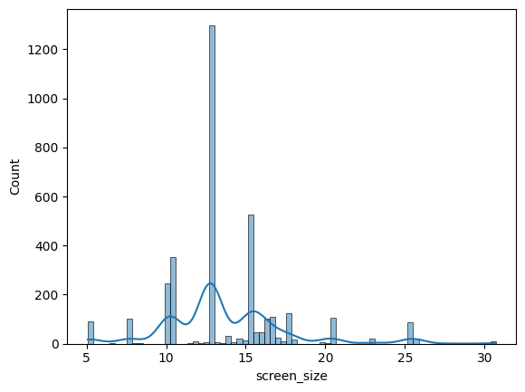

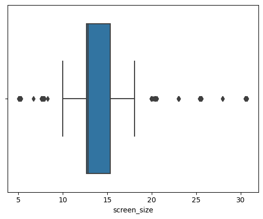

```python
# Univariate analysis for screen size
hist('screen_size',used_device_df)
box('screen_size',used_device_df)
```

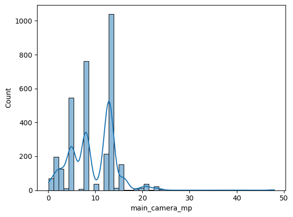

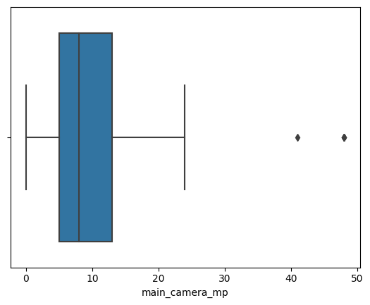

```python
# Univariate analysis for main_camera_mp
hist('main_camera_mp',used_device_df)
box('main_camera_mp',used_device_df)
```

As you can see main camera mp for most of the phones are in the range of 5 to 13mp. It has Average value is 9.46 megapixel. Minimum main camera mp is 0.08 and maximum main camera mp is 48. Main camera mp has median of 8.

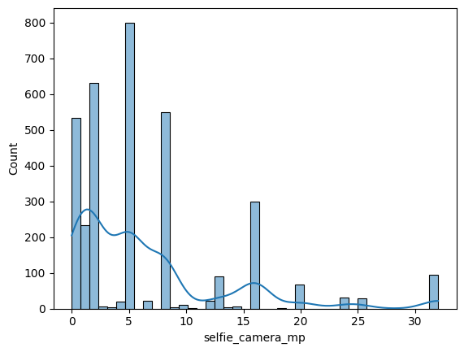

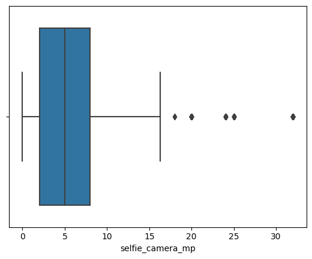

```python
# Univariate analysis for selfie_camera_mp
hist('selfie_camera_mp',used_device_df)
box('selfie_camera_mp',used_device_df)
```

Selfie camera mp for most of the phones are in the range of 2 to 8 mp. Average value is 6.55 megapixel. Minimum selfie camera mp is 0 and maximum selfie camera mp is 32. Selfie camera mp has median of 5.

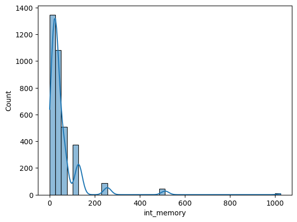

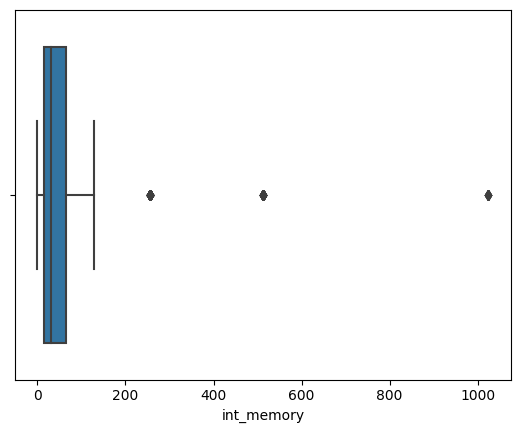

```python
# Univariate analysis for int_memory
sns.histplot(x='int_memory',data=used_device_df,bins=40,kde=True)
plt.show()
box('int_memory',used_device_df)
```

Internal memory for most of the phone are between 16 to 64 gb. Average internal memory is 54 gb. Minimum internal memory is 0.01 gb and maximum internal memory is 1024 gb. Internal memory has median of 32 gb

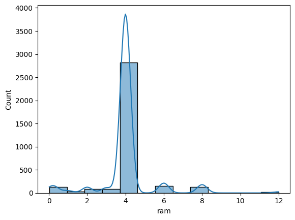

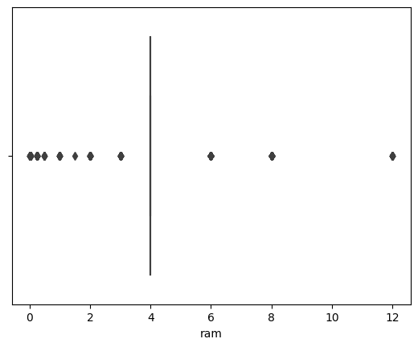

```python
# Univariate analysis for ram
hist('ram',used_device_df)
box('ram',used_device_df)
```

As you can see most of the phone has ram of about 4 gb.Average ram is 4.04 gb. Minimum ram is 0.02 gb and maximum ram is 12 gb. Ram has median of 4 gb

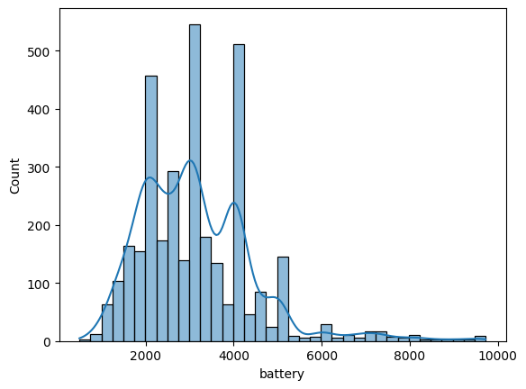

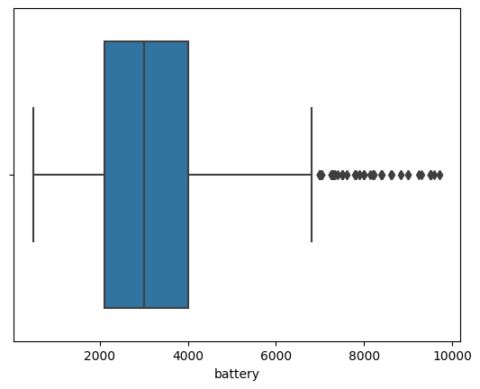

```python
# Univariate analysis for battery
hist('battery',used_device_df)
box('battery',used_device_df)
```

Most of the phone battery capacity is between 2000 to 4000 mah.Average battery capacity is 3133.40 mAh. Minimum battery capacity is 500 mAh and maximum battery capacity is 9720 mAh. Battery capacity has median of 3000 mAh.

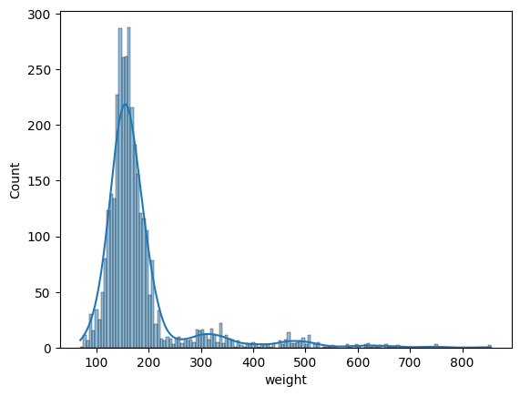

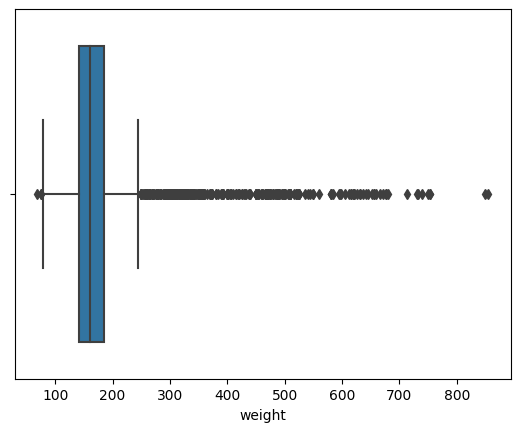

```python
# Univariate analysis for weight:
hist('weight',used_device_df)
box('weight',used_device_df)
```

Most of the phone weight is between 130 to 200 gm.Average weight is 182.75 gm. Minimum weight for the phone is 69 gm and maximum weight for the phone is 855 gm. Weight for the phone has median of 160 gm.

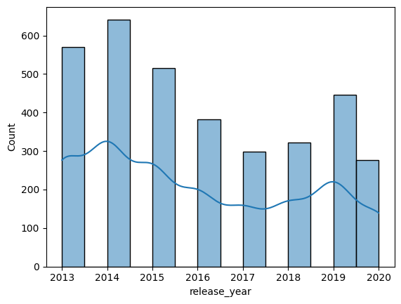

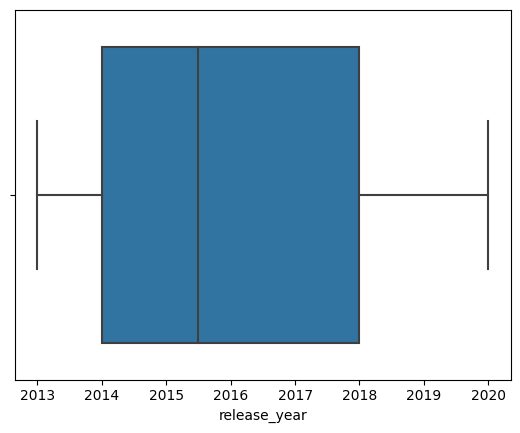

```python
# Univariate analysis for release_year
hist('release_year',used_device_df)
box('release_year',used_device_df)
```

Phone release year is between 2013 to 2020. Most of the year has phone count more then 300. Year 2013 to 2015 has almost more then 500 count for each year.

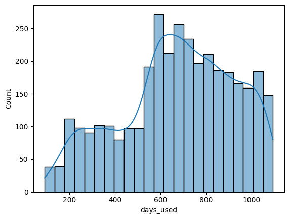

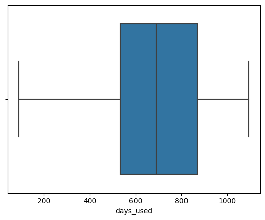

```python
# Univariate analysis for days_used
hist('days_used',used_device_df)
box('days_used',used_device_df)
```

As you can see most of the devices are used more then 500 days to 900 days.

**What does the distribution of normalized used device prices look like?**

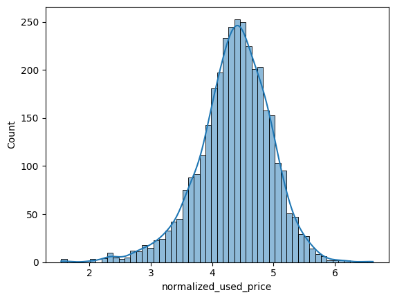

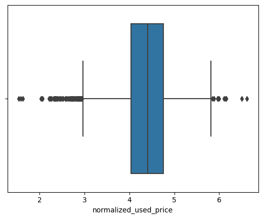

```python
# Univariate analysis for normalized_used_price
hist('normalized_used_price',used_device_df)
box('normalized_used_price',used_device_df)
```

Normalized price for used phone is in between 4 to 4.75 euros and it is normally distributed.Average value for normalized_used_price is 4.37 euros. Minimum value for normalized_used_price is 1.54 euros and maximum value for normalized_used_price is 6.62 euros. Normalized_used_price has median of 4.41 euros.

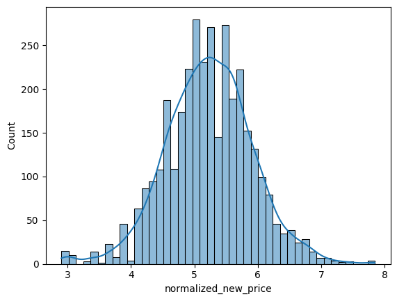

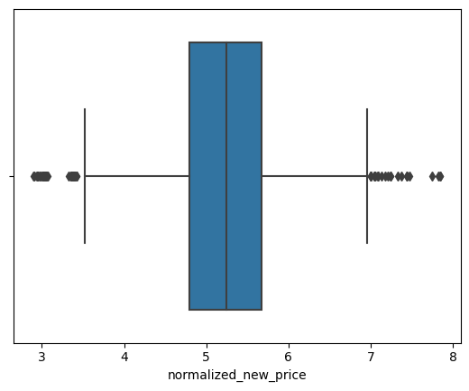

```python
# Univariate analysis for normalized_new_price
hist('normalized_new_price',used_device_df)
box('normalized_new_price',used_device_df)
```

Normlized value for new phone is in between 4.8 to 5.7 euros and it is also normally distributes.Average value for normalized_new_price is 5.23 euros. Minimum value for normalized_new_price is 2.9 euros and maximum value for normalized_new_price is 7.85 euros.Normalized_new_price has median of 5.25 euros.

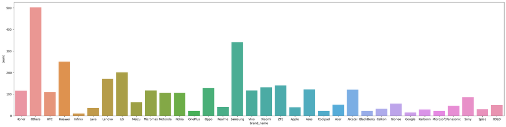

```python
# Univariate analysis for brand name
plt.figure(figsize=(30, 7))
sns.countplot(x='brand_name',data = used_device_df)
```

There are 34 unique brand_name. There are 502 other brand name followed by 341 Samsung brand and 251 Huawei brand phone.

**What percentage of the used device market is dominated by Android devices?**

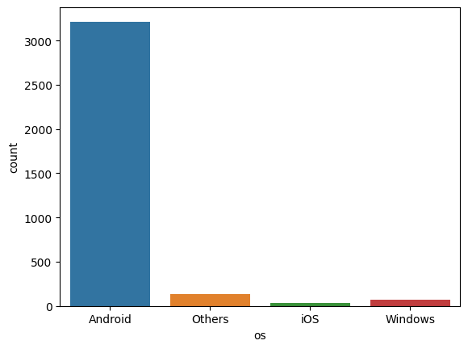

```python
# Univariate analysis for os
sns.countplot(x='os',data = used_device_df)
```

```python
display(used_device_df['os'].value_counts(normalize=True))
display(used_device_df['os'].value_counts())
```

```
Android    0.930515
Others     0.039664
Windows    0.019398
iOS        0.010423
Name: os, dtype: float64
```

```
Android    3214
Others      137
Windows      67
iOS          36
Name: os, dtype: int64
```

As you can see majority of the phone has Android operating system. Almost 93.05% phones are Android operating followed by 3.97% of others.

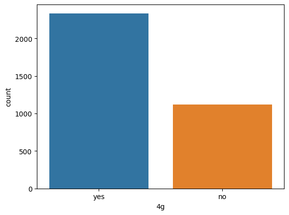

```python
# Univariate analysis for 4g
sns.countplot(x='4g',data = used_device_df)
```

As you can see there are more phone with 4g comapred with non 4g phone

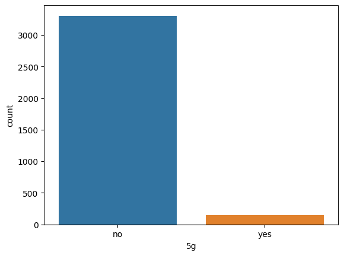

```python
# Univariate analysis for 5g
sns.countplot(x='5g',data = used_device_df)
```

Almost 95% phone does not have 5g network.

### Bivariate Analysis

**Which attributes are highly correlated with the normalized price of a used device?**

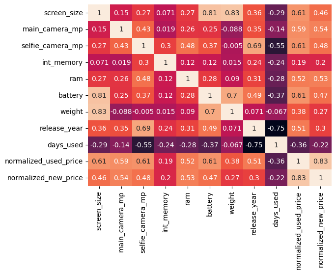

```python
# Finding correlation between all variables
sns.heatmap(used_device_df.corr(),annot=True,cbar=False);
```

As you can see normlized used price of the phone is in positive correaltion with the screen size,main_camera_mp,selfie_camera_mp,ram,battery,release_year, normalized_new_price with corr factor more then 0.5. It is in negative correaltion with days_used with factor of -0.36. It is highly correalated with normalized_new_price with corr factor 0.83.

**How does the amount of RAM vary with the brand?**

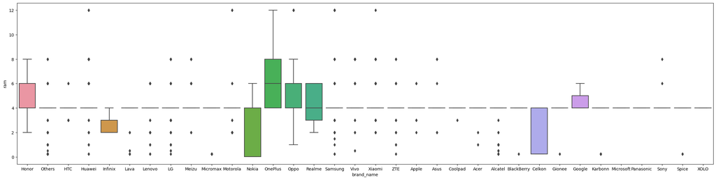

```python
# brand_name vs ram of the phone
plt.figure(figsize=(30, 7))
sns.boxplot(x='brand_name',y='ram',data=used_device_df)
```

As you can see most of brand has 4 gb ram for the phone. Different ram sizes are also avalable for different brand phone but our data has majority of the phones produced by different brand in 4 gb size.

**How does the weight vary for phones and tablets offering large batteries (more than 4500 mAh)?**

```python
# Weight vs large battery correlation
#getting dataframe with battery > 4500 mah
df2 = used_device_df[used_device_df['battery'] > 4500]
corr = df2['battery'].corr(df2['weight'])
corr
```

```
0.7576216347513972
```

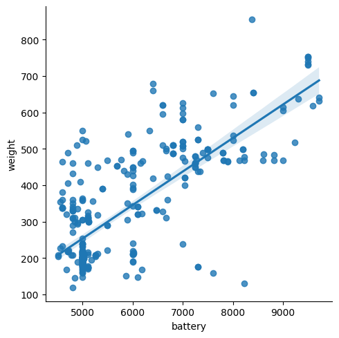

```python
# Weight vs large battery lm plot
sns.lmplot(data=df2, x='battery', y='weight');
```

As you can see the weight of the phone and battery is positively correlated with factor of 0.76.

**How many phones and tablets are available across different brands with a screen size larger than 6 inches**

```python
# Different phones and tablets available across different brands with a screen size larger than 6 inches
df3 = used_device_df[used_device_df['screen_size'] > 6*2.54]
df3['brand_name'].value_counts()
print('Different phones and tablets available across different brands with a screen size larger than 6 inches are as follows:','\n',df3['brand_name'].value_counts())
```

```
Different phones and tablets available across different brands with a screen size larger than 6 inches are as follows:
 Huawei       149
Samsung      119
Others        99
Vivo          80
Honor         72
Oppo          70
Xiaomi        69
Lenovo        69
LG            59
Motorola      42
Asus          41
Realme        40
Alcatel       26
Apple         24
Acer          19
ZTE           17
Meizu         17
OnePlus       16
Nokia         15
Sony          12
Infinix       10
HTC            7
Micromax       7
Google         4
Coolpad        3
Gionee         3
XOLO           3
Karbonn        2
Panasonic      2
Spice          2
Microsoft      1
Name: brand_name, dtype: int64
```

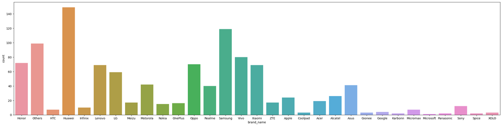

```python
# Analyzing different phones and tablets available across different brands with a screen size larger than 6 inches
plt.figure(figsize=(30, 7))
sns.countplot(x='brand_name',data=df3)
```

As you can see Huawei top the list with 149 phones followed by Samsung with 119 phones and other with 99 phones has screen size more then 6 inch.